# Data %>% Power %>% R

You ready?

### R

- a powerful open source programming language
- available in the database as Oracle R Enterprise
- that lets you do virtually anything…

### Especially (but not only)

- Statistics
- Machine Learning
- Visualization
- Presentation (evidently)

### Fine.

But I'm a SQL girl.

Now I gotta learn something totally new?

### Don't fear

Enter

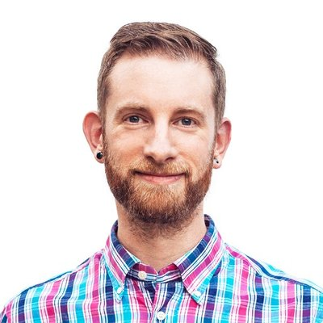

*“All tidy datasets are alike, every untidy dataset is untidy in its own way.”*  
(Hadley Wickham)

### The tidyverse

```r
library(readr)
library(dplyr)
library(tidyr)
library(ggplot2)
library(lubridate)
```

### But we're not just gonna do R syntax.

Let's look at some real data!

### Everyone talks about the weather

I certainly do.

### This is what I want for winter.

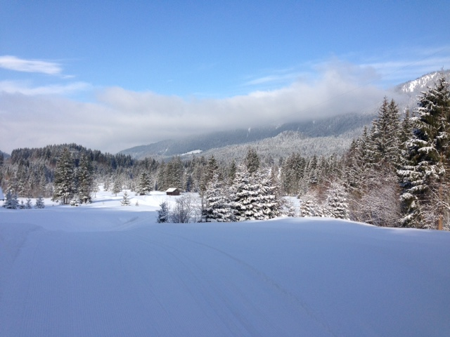

### This is what I get.

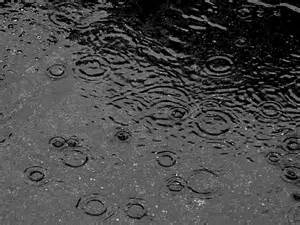

### Let's try to find out about the future

- Berkeley Earth Surface Temperature Study
  - https://www.kaggle.com/berkeleyearth/climate-change-earth-surface-temperature-data)
  - monthly averages, 1743-2013
- Weather data from weather station Munich airport
  - retrieved from www.wunderground.com
  - daily averages, 1997-2015

### Berkeley Earth global land temperatures

```r
df <- read_csv('data/GlobalLandTemperaturesByCity.csv')
head(df,3)
```

```
# A tibble: 3 × 7
          dt AverageTemperature AverageTemperatureUncertainty  City
      <date>              <dbl>                         <dbl> <chr>
1 1743-11-01              6.068                         1.737 Århus
2 1743-12-01                 NA                            NA Århus
3 1744-01-01                 NA                            NA Århus
# ... with 3 more variables: Country <chr>, Latitude <chr>,
#   Longitude <chr>
```

### Before we even start

*Let's get ourselves some nicer variable names.*

```r
df <- rename(df,
             avg_temp = AverageTemperature,
             avg_temp_95p = AverageTemperatureUncertainty,
             city = City,
             country = Country,
             lat = Latitude,
             long = Longitude)
head(df,3)
```

```
# A tibble: 3 × 7
          dt avg_temp avg_temp_95p  city country    lat   long
      <date>    <dbl>        <dbl> <chr>   <chr>  <chr>  <chr>
1 1743-11-01    6.068        1.737 Århus Denmark 57.05N 10.33E
2 1743-12-01       NA           NA Århus Denmark 57.05N 10.33E
3 1744-01-01       NA           NA Århus Denmark 57.05N 10.33E
```

### distinct (SELECT distinct)

*First thing I'd like to know: Which locations are available?*

```r
head(distinct(df, country), 3)
```

```
# A tibble: 3 × 1
     country
       <chr>
1    Denmark
2     Turkey
3 Kazakhstan
```

```r
head(distinct(df, city), 3)
```

```
# A tibble: 3 × 1
   city
  <chr>
1 Århus
2 Çorlu
3 Çorum
```

### filter (WHERE)

*Let's see some Munich data!*

```r
head(filter(df, city == 'Munich'), 3)
```

```
# A tibble: 3 × 7
          dt avg_temp avg_temp_95p   city country    lat   long
      <date>    <dbl>        <dbl>  <chr>   <chr>  <chr>  <chr>
1 1743-11-01    1.323        1.783 Munich Germany 47.42N 10.66E
2 1743-12-01       NA           NA Munich Germany 47.42N 10.66E
3 1744-01-01       NA           NA Munich Germany 47.42N 10.66E
```

### filter (combining predicates)

```r
# AND
head(filter(df, city == 'Munich' & year(dt) > 2000), 3)
```

```
# A tibble: 3 × 7
          dt avg_temp avg_temp_95p   city country    lat   long
      <date>    <dbl>        <dbl>  <chr>   <chr>  <chr>  <chr>
1 2001-01-01   -3.162        0.396 Munich Germany 47.42N 10.66E
2 2001-02-01   -1.221        0.755 Munich Germany 47.42N 10.66E
3 2001-03-01    3.165        0.512 Munich Germany 47.42N 10.66E
```

```r
# OR
head(filter(df, city == 'Munich' | year(dt) > 2000), 3)
```

```
# A tibble: 3 × 7
          dt avg_temp avg_temp_95p  city country    lat   long
      <date>    <dbl>        <dbl> <chr>   <chr>  <chr>  <chr>
1 2001-01-01    1.918        0.381 Århus Denmark 57.05N 10.33E
2 2001-02-01    0.241        0.328 Århus Denmark 57.05N 10.33E
3 2001-03-01    1.310        0.236 Århus Denmark 57.05N 10.33E
```

### select (SELECT)

*Just concentrate on the important variables.*

```r
head(select(filter(df, city == 'Munich'), dt, avg_temp, avg_temp_95p), 8)
```

```
# A tibble: 8 × 3
          dt avg_temp avg_temp_95p
      <date>    <dbl>        <dbl>
1 1743-11-01    1.323        1.783
2 1743-12-01       NA           NA
3 1744-01-01       NA           NA
4 1744-02-01       NA           NA
5 1744-03-01       NA           NA
6 1744-04-01    5.498        2.267
7 1744-05-01    7.918        1.603
8 1744-06-01   11.070        1.584
```

### arrange (ORDER BY)

*Coldest months ever.*

```r
head(arrange(select(filter(df, city == 'Munich'), dt, avg_temp), avg_temp), 8)
```

```
# A tibble: 8 × 2
          dt avg_temp
      <date>    <dbl>
1 1956-02-01  -12.008
2 1830-01-01  -11.510
3 1767-01-01  -11.384
4 1929-02-01  -11.168
5 1795-01-01  -11.019
6 1942-01-01  -10.785
7 1940-01-01  -10.643
8 1895-02-01  -10.551
```

### All these parens are starting to be a pain...

What if we added still further data processing steps?

### Enter: %>%

What you see: **x %>% f(y)**  
What you get: **f(x, y)**

### Coldest months, with the %>%!

```r
df %>% filter(city == 'Munich') %>% select(dt, avg_temp) %>% arrange(avg_temp) %>% head(8)
```

```
# A tibble: 8 × 2
          dt avg_temp
      <date>    <dbl>
1 1956-02-01  -12.008
2 1830-01-01  -11.510
3 1767-01-01  -11.384
4 1929-02-01  -11.168
5 1795-01-01  -11.019
6 1942-01-01  -10.785
7 1940-01-01  -10.643
8 1895-02-01  -10.551
```

*Now that we have %>%, we can tackle more complex statements.*

### group_by (GROUP BY)

*What countries have most measurements?*

```r
df %>% group_by(country) %>% summarise(count=n()) %>% arrange(count %>% desc()) %>% head(8)
```

```
# A tibble: 8 × 2
        country   count
          <chr>   <int>
1         India 1014906
2         China  827802
3 United States  687289
4        Brazil  475580
5        Russia  461234
6         Japan  358669
7     Indonesia  323255
8       Germany  262359
```

### group_by (multiple summaries)

*What are the average, min and max monthly temperatures in Germany after 1949?*

```r
df %>% filter(country == 'Germany', !is.na(avg_temp), year(dt) > 1949) %>% group_by(month(dt)) %>% summarise(count = n(), avg = mean(avg_temp), min = min(avg_temp), max = max(avg_temp))
```

```
# A tibble: 12 × 5
   `month(dt)` count        avg     min    max
         <dbl> <int>      <dbl>   <dbl>  <dbl>
1            1  5184  0.3329331 -10.256  6.070
2            2  5184  1.1155843 -12.008  7.233
3            3  5184  4.5513194  -3.846  8.718
4            4  5184  8.2728137   1.122 13.754
5            5  5184 12.9169965   5.601 16.602
6            6  5184 15.9862500   9.824 21.631
7            7  5184 17.8328285  11.697 23.795
8            8  5184 17.4978752  11.390 23.111
9            9  5103 14.0571383   7.233 18.444
10          10  5103  9.4110645   0.759 13.857
11          11  5103  4.6673114  -2.601  9.127
12          12  5103  1.3649677  -8.483  6.217
```

### JOINs: inner_join, left_join, anti_join ...

*Let's join the two different data sources on the month column:*

```r
daily_1997_2015 <- read_csv('data/munich_1997_2015.csv')
monthly_1997_2015 <- daily_1997_2015 %>% group_by(month = floor_date(daily_1997_2015$day, "month")) %>% summarise(mean_temp = mean(mean_temp))

df_1949 <- df %>% select(dt, avg_temp) %>% filter(year(dt) > 1949)

df_1949 %>% inner_join(monthly_1997_2015, by = c("dt" = "month")) %>% head(3)
```

```
# A tibble: 3 × 3
          dt avg_temp mean_temp
      <date>    <dbl>     <dbl>
1 1997-01-01   -0.742 -3.580645
2 1997-02-01    2.771  3.392857
3 1997-03-01    4.089  6.064516
```

### UNION & friends: union, setdiff, intersect

*Union of pre-2016 and 2016 Munich daily weather data.*

```r
daily_2016 <- read_csv('data/munich_2016.csv')
daily_1997_2015 %>% dplyr::union(daily_2016) %>% arrange(day) %>% head(8)
```

```
# A tibble: 8 × 23
         day max_temp mean_temp min_temp   dew mean_dew min_dew max_hum
      <date>    <int>     <int>    <int> <int>    <int>   <int>   <int>
1 1997-01-01       -8       -12      -16   -13      -14     -17      92
2 1997-01-02        0        -8      -16    -9      -13     -18      92
3 1997-01-03       -4        -6       -7    -6       -8      -9      93
4 1997-01-04       -3        -4       -5    -5       -6      -6      93
5 1997-01-05       -1        -3       -6    -4       -5      -7     100
6 1997-01-06       -2        -3       -4    -4       -5      -6      93
7 1997-01-07        0        -4       -9    -6       -9     -10      93
8 1997-01-08        0        -3       -7    -7       -7      -8     100
# ... with 15 more variables: mean_hum <int>, min_hum <int>,
#   max_hpa <int>, mean_hpa <int>, min_hpa <int>, max_visib <int>,
#   mean_visib <int>, min_visib <int>, max_wind <int>, mean_wind <int>,
#   max_gust <int>, prep <dbl>, cloud <int>, events <chr>, winddir <chr>
```

### Window functions (1)

*5% hottest days in Munich in 2016.*

```r
 filter(daily_2016, cume_dist(desc(mean_temp)) < 0.05) %>% select(day, mean_temp) %>% arrange(desc(mean_temp))
```

```
# A tibble: 5 × 2
         day mean_temp
      <date>     <int>
1 2016-07-11        24
2 2016-06-24        22
3 2016-06-25        22
4 2016-07-09        22
5 2016-07-30        22
```

### Window functions (2)

*Top 3 coldest days in Munich in 2016.*

```r
 filter(daily_2016, dense_rank(mean_temp) < 4) %>% select(day, mean_temp) %>% arrange(mean_temp)
```

```
# A tibble: 4 × 2
         day mean_temp
      <date>     <int>
1 2016-01-22       -10
2 2016-01-19        -8
3 2016-01-18        -7
4 2016-01-20        -7
```

### Window functions

*Consecutive days where mean temperatures differ by more than 5 degrees.*

```r
daily_2016 %>% mutate(yesterday_temp = lag(mean_temp)) %>% filter(abs(yesterday_temp - mean_temp) > 5) %>% select(day, mean_temp, yesterday_temp)
```

```
# A tibble: 6 × 3
         day mean_temp yesterday_temp
      <date>     <int>          <int>
1 2016-02-01        10              4
2 2016-02-21        11              3
3 2016-06-26        16             22
4 2016-07-12        18             24
5 2016-08-05        14             21
6 2016-08-13        19             13
```

### OK. So we can do all that with R.

How about what we CAN'T do in SQL?

### There was this original question about snow.

Let's see what we might predict about the future.

### The grammar of graphics: visualization with ggplot2

*How cold is it in Munich, compared to, say, Bern or Oslo?*

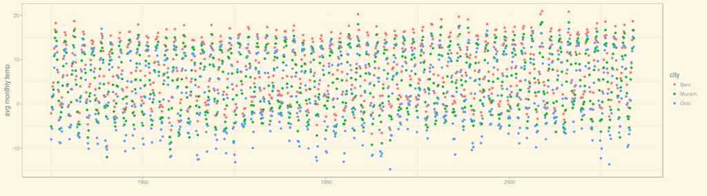

```r
df_cities <- df %>% filter(city %in% c("Munich", "Bern", "Oslo"), year(dt) > 1949, !is.na(avg_temp))
(p_1950 <- ggplot(df_cities, aes(dt, avg_temp, color = city)) + geom_point() + xlab("") + ylab("avg monthly temp") + theme_solarized())
```

### Can we see a trend?

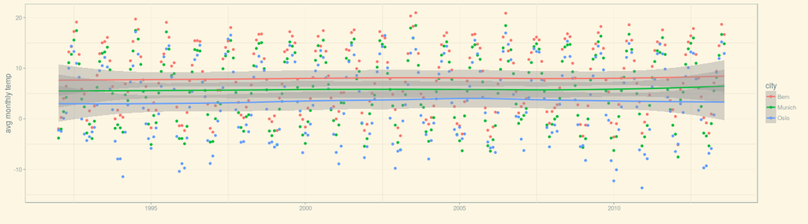

```r
start_time <- as.Date("1992-01-01")
end_time <- as.Date("2013-08-01")
limits <- c(start_time,end_time)
(p_1992 <- p_1950 + (scale_x_date(limits=limits)) + geom_smooth(se = TRUE))
```

### Let's concentrate on Munich.

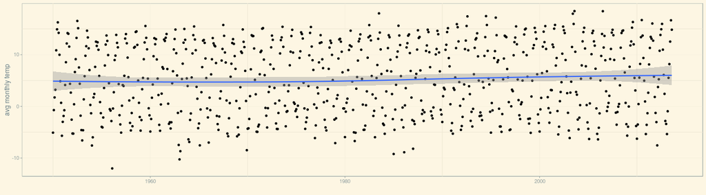

```r
df_munich <- df_cities %>% filter(city == 'Munich')
p_munich_1950 <- ggplot(df_munich, aes(dt, avg_temp)) + geom_point() + xlab("") + ylab("avg monthly temp") + theme_solarized() + geom_smooth()
p_munich_1950
```

### Difficult.

There might be a trend, or there might not.

Of course, there is not just one smoothing algorithm only.

### LOESS (Local Polynomial Regression Fitting) vs. LM (Linear Model)

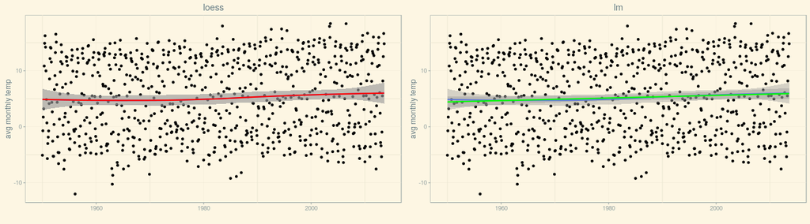

```r
loess <- p_munich_1950 + stat_smooth(method = "loess", colour = "red") + labs(title = 'loess')
lm <- p_munich_1950 + stat_smooth(method = "lm", color = "green") + labs(title = 'lm')
grid.arrange(loess, lm, ncol=2)
```

### So?

We need to dig deeper and really analyze those time series.

### Time series: A quick first glance

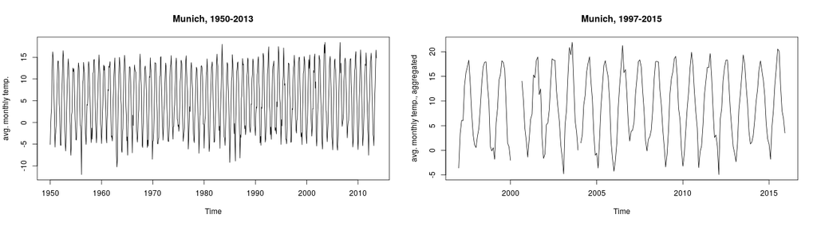

```r
ts_1950 <- ts(df_munich$avg_temp, start = c(1950,1), end=c(2013,8), frequency = 12)
ts_1997 <- ts(monthly_1997_2015$mean_temp, start = c(1997,1), frequency = 12)
par(mfrow=c(1,2))
plot(ts_1950, main = 'Munich, 1950-2013', ylab = 'avg. monthly temp.')
plot(ts_1997,  main = 'Munich, 1997-2015', ylab = 'avg. monthly temp., aggregated')
par(mfrow=c(1,1))
```

### Time series decomposition

Time series may be decomposed into different effects:

- trend
- seasonal (if available)
- remainder

### Time series decomposition: Berkeley Earth data, 1950-2013

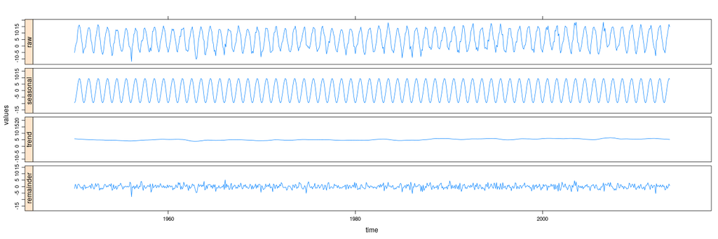

```r
library(stlplus)
fit <- stlplus(ts_1950, s.window="periodic", t.window=37)
plot(fit)
```

### Time series decomposition: Munich weather data, 1997-2015

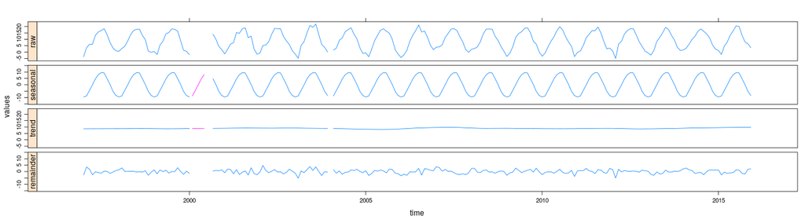

```r
fit <- stlplus(ts_1997, s.window="periodic", t.window=37)
plot(fit)
```

### Exponential Smoothing

- Predicted values at time t+1 are weighted averages of values at times t, t-1, t-2 …: \( \hat{y}_{T+1|T} = \alpha y_T + \alpha(1-\alpha) y_{T-1} + \alpha(1-\alpha)^2 y_{T-2}+ \cdots \)
- Can also model trends and seasonal effects (Holt-Winters)

### State Space Models

- Conceptually equivalent to exponential smoothing
- BUT also generate prediction intervals!
- http://www.exponentialsmoothing.net/
- R: **ets()** function in **forecast** package

### ets()

- When called without parameters, **ets()** determines a suitable model itself
- Using maximum likelihood estimation

### ets(): Berkeley Earth data, 1950-2013

```r
library(forecast)
fit <- ets(ts_1950)
summary(fit)
```

```
ETS(A,N,A)

Call:
 ets(y = ts_1950)

  Smoothing parameters:
    alpha = 0.0202
    gamma = 1e-04

  Initial states:
    l = 5.3364
    s=-8.3652 -4.6693 0.7114 5.4325 8.8662 9.3076
           7.3288 4.1447 -0.677 -4.3463 -8.2749 -9.4586

  sigma:  1.7217

     AIC     AICc      BIC
5932.003 5932.644 6001.581

Training set error measures:
                     ME    RMSE      MAE      MPE     MAPE      MASE
Training set 0.02606379 1.72165 1.345745 22.85555 103.3956 0.7208272
                   ACF1
Training set 0.09684748
```

### ets(): Berkeley Earth data, 1950-2013

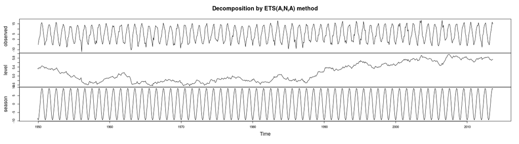

```r
# Plot the smoothed components - no trend!
plot(fit)
```

### ets(): Berkeley Earth data, 1950-2013

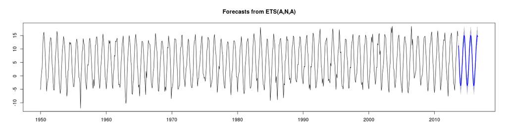

```r
# Forecast next 3 years
plot(forecast(fit, h=36))
```

### ets(): Munich weather data, 1997-2015

```r
fit <- ets(ts_1997)
summary(fit)
```

```
ETS(A,N,A)

Call:
 ets(y = ts_1997)

  Smoothing parameters:
    alpha = 0.2459
    gamma = 1e-04

  Initial states:
    l = 9.0339
    s=-9.1638 -8.2689 -4.6247 0.2518 4.8168 8.9262
           9.9013 7.7434 4.1498 0.3801 -4.9118 -9.2002

  sigma:  1.6258

     AIC     AICc      BIC
878.6766 882.4562 923.1193

Training set error measures:
                     ME     RMSE      MAE      MPE     MAPE      MASE
Training set 0.03058885 1.625765 1.320291 4.385226 40.82934 0.7068611
                  ACF1
Training set 0.1407344
```

### ets(): Munich weather data, 1997-2015

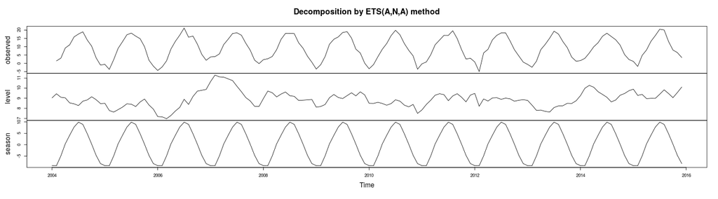

```r
# Plot the smoothed components - no trend!
plot(fit)
```

### ets(): Munich weather data, 1997-2015

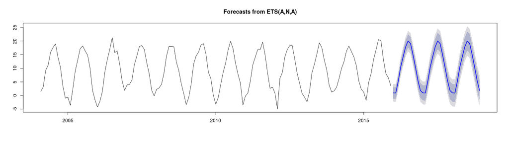

```r
# Forecast next 3 years
plot(forecast(fit, h=36))
```

### ARIMA

- **AR(p)**:  
  autoregressive: \[ y_{t} = c + \phi_{1}y_{t-1} + \phi_{2}y_{t-2} + \dots + \phi_{p}y_{t-p} + e_{t} \]
- **I(d)**:  
  number of times differencing has to be applied to obtain a stationary series
- **MA(q)**:  
  moving average: \[ y_{t} = c + e_t + \theta_{1}e_{t-1} + \theta_{2}e_{t-2} + \dots + \theta_{q}e_{t-q} \]

*Stationarity: If a time series \( y_{t} \) is stationary, then for all \( s \), the distribution of (\( y_{t} \),…, \( y_{t+s} \)) does not depend on \( t \).*

### Stationarity: ACF and PACF

Berkeley Earth data, 1950-2013

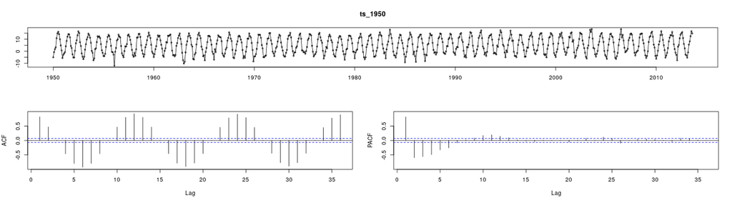

```r
tsdisplay(ts_1950)
```

### Stationarity: ACF and PACF

Munich weather data, 1997-2015

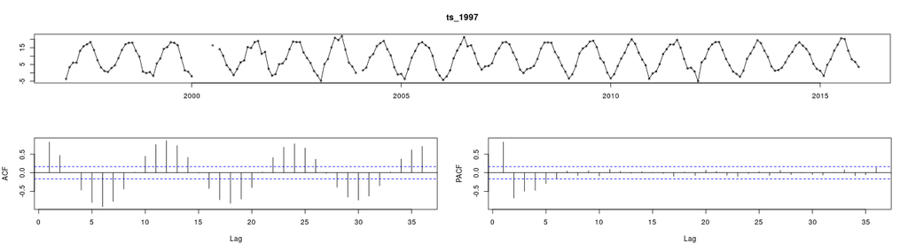

```r
tsdisplay(ts_1997)
```

### Cyclostationary process

Mean and variance are constant for seasonally corresponding measurements.

### How do we decide which p,d,q to use for ARIMA?

Just use auto.arima().  
(But see later.)

### ARIMA: Berkeley Earth data, 1950-2013

```r
fit <- auto.arima(ts_1950)
summary(fit)
```

```
Series: ts_1950
ARIMA(1,0,5)(0,0,2)[12] with non-zero mean

Coefficients:
         ar1      ma1      ma2      ma3      ma4      ma5    sma1    sma2
      0.6895  -0.0794  -0.0408  -0.1266  -0.3003  -0.2461  0.3972  0.3555
s.e.  0.0409   0.0535   0.0346   0.0389   0.0370   0.0347  0.0413  0.0342
      intercept
         5.1667
s.e.     0.1137

sigma^2 estimated as 7.242:  log likelihood=-1838.47
AIC=3696.94   AICc=3697.24   BIC=3743.33

Training set error measures:
                       ME     RMSE      MAE      MPE     MAPE     MASE
Training set -0.001132392 2.675279 2.121494 23.30576 116.9652 1.136345
                   ACF1
Training set 0.03740769
```

### ARIMA: Munich weather data, 1997-2015

```r
fit <- auto.arima(ts_1997)
summary(fit)
```

```
Series: ts_1997
ARIMA(0,0,4)(0,0,2)[12] with zero mean

Coefficients:
         ma1     ma2     ma3     ma4    sma1    sma2
      0.9293  0.8470  0.6736  0.3146  0.6144  0.3083
s.e.  0.0763  0.0973  0.0754  0.0652  0.0846  0.0590

sigma^2 estimated as 9.321:  log likelihood=-566.86
AIC=1147.72   AICc=1148.22   BIC=1171.72

Training set error measures:
                   ME     RMSE      MAE      MPE    MAPE     MASE
Training set 1.275131 3.059881 2.417012 10.06209 85.7372 1.283957
                  ACF1
Training set -0.141014
```

### Let's get forecasting!

Wait.

ARIMA forecasts are based on the assumption that residuals are uncorrelated and normally distributed.

### Residuals: Autocorrelation

Berkeley Earth data, 1950-2013

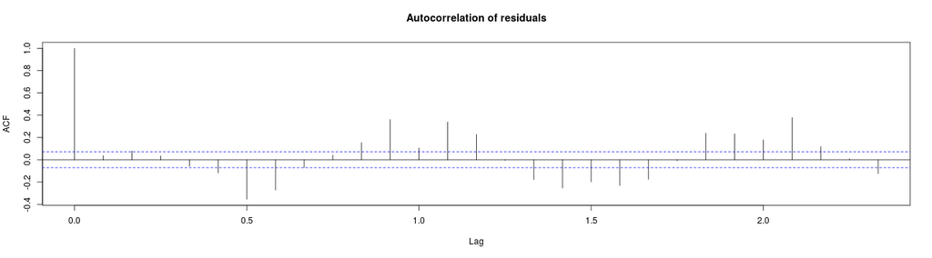

```r
fit <- auto.arima(ts_1950)
res <- fit$residuals
acf <- acf(res, main='Autocorrelation of residuals')
```

### Allowing for more parameters: Berkeley Earth data, 1950-2013

```r
fit <- auto.arima(ts_1950, max.order = 10, stepwise=FALSE)
summary(fit)
```

```
Series: ts_1950
ARIMA(5,0,1)(0,0,2)[12] with non-zero mean

Coefficients:
         ar1      ar2      ar3      ar4      ar5      ma1    sma1    sma2
      0.8397  -0.0588  -0.0691  -0.2087  -0.2071  -0.4538  0.0869  0.1422
s.e.  0.0531   0.0516   0.0471   0.0462   0.0436   0.0437  0.0368  0.0371
      intercept
         5.1709
s.e.     0.0701

sigma^2 estimated as 4.182:  log likelihood=-1629.11
AIC=3278.22   AICc=3278.51   BIC=3324.61

Training set error measures:
                       ME     RMSE      MAE        MPE     MAPE      MASE
Training set -0.003793625 2.033009 1.607367 -0.2079903 110.0913 0.8609609
                   ACF1
Training set -0.0228192
```

### Forecast: Berkeley Earth data, 1950-2013

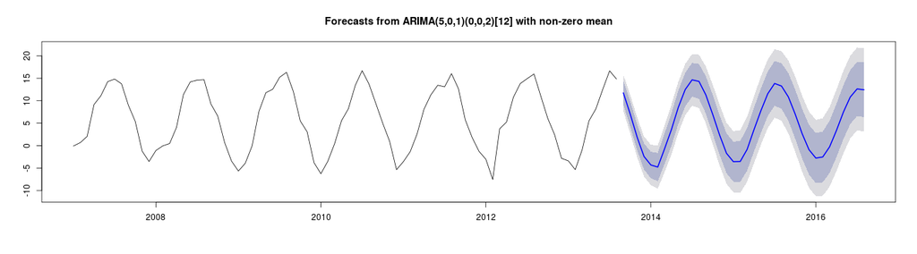

```r
plot(forecast(fit,h=36),include=80)
```

### Allowing for more parameters: Munich weather data, 1997-2015

```r
fit <- auto.arima(ts_1997, max.order = 10, stepwise=FALSE)
summary(fit)
```

```
Series: ts_1997
ARIMA(4,0,0)(0,0,2)[12] with non-zero mean

Coefficients:
         ar1     ar2      ar3      ar4    sma1     sma2  intercept
      0.6874  0.1731  -0.0106  -0.5435  0.0501  -0.0097     8.9000
s.e.  0.0577  0.0751   0.0750   0.0581  0.0772   0.0706     0.2174

sigma^2 estimated as 4.597:  log likelihood=-485.93
AIC=987.87   AICc=988.52   BIC=1015.3

Training set error measures:
                       ME     RMSE      MAE      MPE     MAPE      MASE
Training set -0.008284777 2.144125 1.683188 27.02366 84.54225 0.8941374
                   ACF1
Training set -0.1716898
```

### Forecast: Munich weather data, 1997-2015

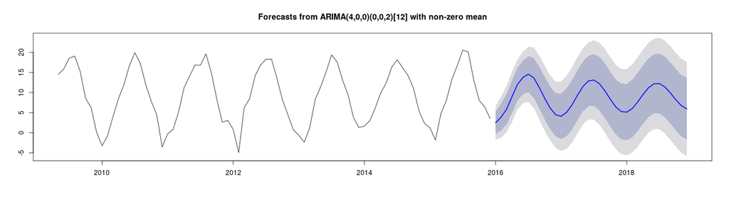

```r
plot(forecast(fit,h=36),include=80)
```

### Oops

What happened?

- ARIMA has problems with too few data points
- ARIMA works better with the longer series
- while ETS handles the shorter series better
- larger uncertainty intervals with ARIMA than with ETS

### Beyond the weather ...

- Forecasting is required (and done!) everywhere
- R gives you all the tools you need
- you need to know what you're doing though!

### Data Science

… is about more than just having data.

It needs (a bit of) science get to the insights!

### Let's start doing some data science

Thank you!